# Pseudo-bulk replicates & Peak calling

### MA Plot

- for visual representation of genomic data
- differences between measurements taken in two samples
- M = log ratio (difference between logs) $M = \log_{2}(R/G) = \log_{2}(R)-\log_{2}(G)$ with $R$ and $G$ being two different conditions.
- A = average log intensity $A = \frac{1}{2}\log_{2}(R)+\log_{2}(G)$
- Peaks with similar accessibility values in both conditions will cluster around $M=0$. These indicate no significant differences between the conditions.
- Points away from $M=0$ indicate significant differences. In our case a region is more accessible if the point is above and less accessible if the point is below $M=0$.
- The plot does not show p-values, therefore, we cannot tell which differences are statistically significant. For this we would have to use a volcano plot.

For example we can plot marker peaks (up/downregulated) in Erythroid cell type compared to the other cell types.

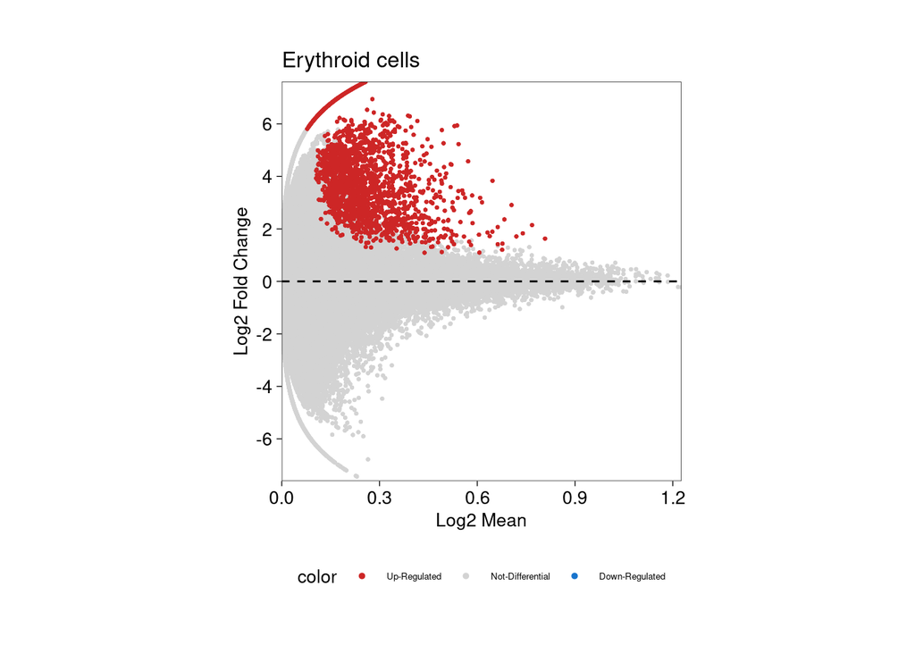

```r
ma <- plotMarkers(seMarker = markersPeaks, name = "Erythroid",
                 cutOff = "FDR <= 0.01 & Log2FC >= 1", plotAs = "MA") +
  labs(title = "Erythroid cells")
ma
## Warning: Removed 59 rows containing missing values (geom_point_rast).
```

### Volcano Plot

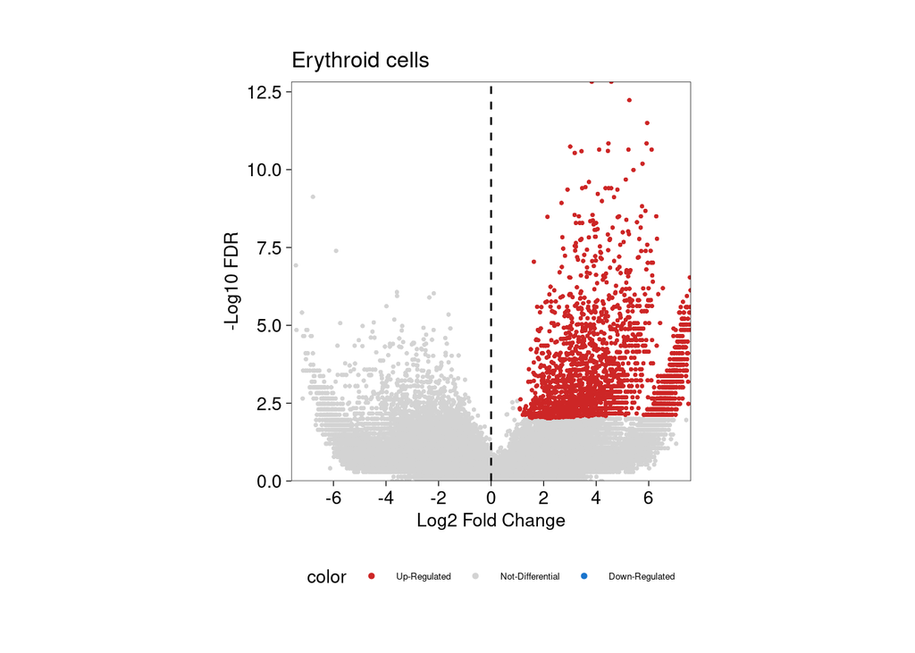

```r
vp = plotMarkers(seMarker = markersPeaks, name = "Erythroid",
                 cutOff = "FDR <= 0.01 & Log2FC >= 1", plotAs = "Volcano")
vp + labs(title = "Erythroid cells")
## Warning: Removed 59 rows containing missing values (geom_point_rast).
```

### Marker Peaks in Browser Tracks

We can also overlay the peaks with the Browser Tracks. We pass the peak regions to the `features` parameter in `plotBrowserTrack()`. An additional BED-style track will be added to the track plot.

For example we can plot the GATA1 gene via the `geneSymbol` parameter.

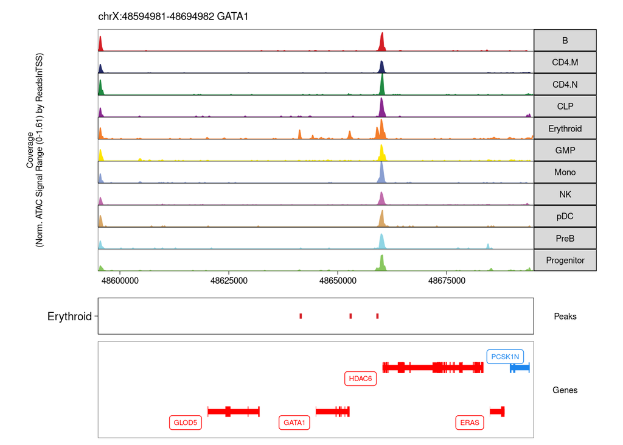

```r
p <- plotBrowserTrack(
    ArchRProj = proj3,
    groupBy = "Clusters2",
    geneSymbol = c("GATA1"),
    features =  getMarkers(markersPeaks, cutOff = "FDR <= 0.1 & Log2FC >= 1", returnGR = TRUE)["Erythroid"],
    upstream = 50000,
    downstream = 50000,
    title = "GATA1"
)
## GRanges object with 1 range and 2 metadata columns:
##       seqnames            ranges strand |     gene_id      symbol
##          <Rle>         <IRanges>  <Rle> | <character> <character>
##   [1]     chrX 48644982-48652717      + |        2623       GATA1
##   -------
##   seqinfo: 24 sequences from hg19 genome
## Warning: `guides(<scale> = FALSE)` is deprecated. Please use `guides(<scale> =
## "none")` instead.

## Warning: `guides(<scale> = FALSE)` is deprecated. Please use `guides(<scale> =
## "none")` instead.

## Warning: `guides(<scale> = FALSE)` is deprecated. Please use `guides(<scale> =
## "none")` instead.


grid::grid.newpage()
grid::grid.draw(p$GATA1)
```

## Pairwise testing between groups

We can also perform differential test between two cell types.

For example, we can test for differences between “Erythroid” and “Progenitor” cell type.

```r
markerTest <- getMarkerFeatures(
  ArchRProj = proj3,
  useMatrix = "PeakMatrix",
  groupBy = "Clusters2",
  testMethod = "wilcoxon",
  bias = c("TSSEnrichment", "log10(nFrags)"),
  useGroups = "Erythroid",
  bgdGroups = "Progenitor"
)
```

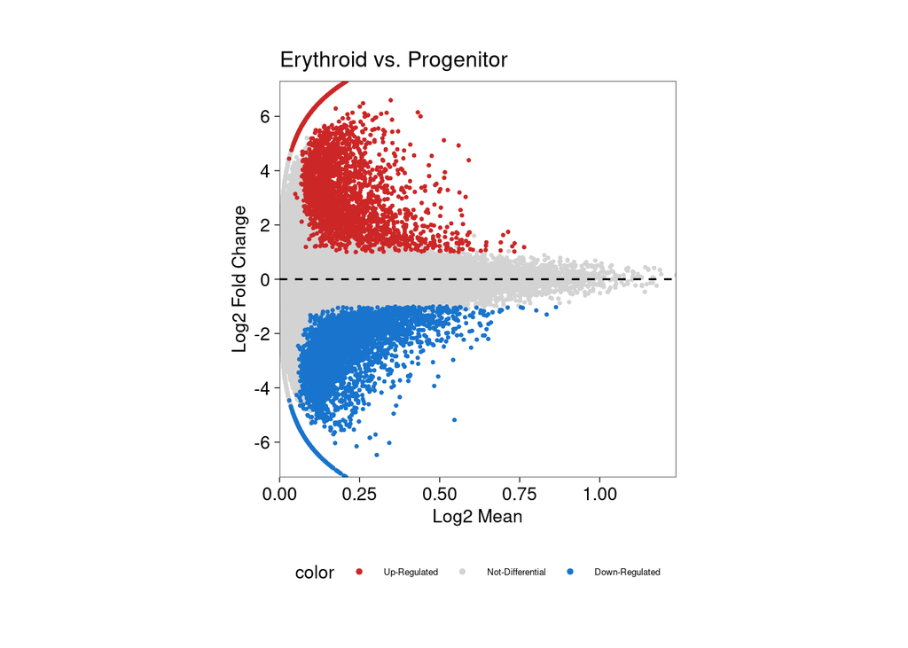

```r
ma <- plotMarkers(seMarker = markerTest, # a summarized experiment obejct returned by the getMarkerFeatures() function
                  name = "Erythroid",
                  cutOff = "FDR <= 0.1 & abs(Log2FC) >= 1",
                  plotAs = "MA")
ma + labs(title = "Erythroid vs. Progenitor")
## Warning: Removed 44 rows containing missing values (geom_point_rast).
```

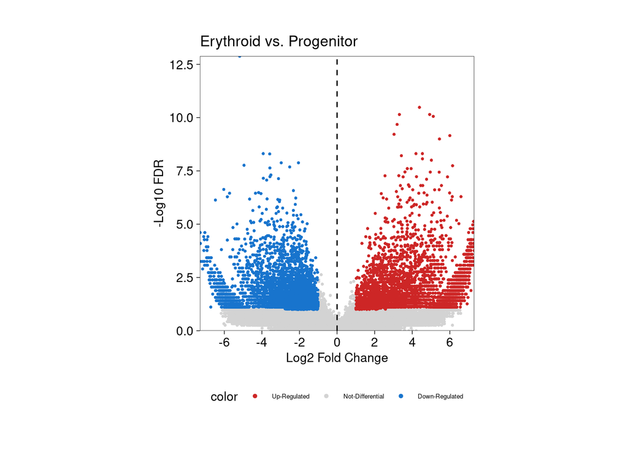

[output not shown]

```r
v <- plotMarkers(seMarker = markerTest,
                 name = "Erythroid",
                 cutOff = "FDR <= 0.1 & abs(Log2FC) >= 1",
                 plotAs = "Volcano")
v + labs(title = "Erythroid vs. Progenitor")
## Warning: Removed 44 rows containing missing values (geom_point_rast).
```